# ANALÍTICA Y CIENCIA DE DATOS PARA NEGOCIOS: DETECCIÓN Y MANEJO DE VALORES EXTREMOS (ANALYTICS AND DATA SCIENCE FOR BUSINESS: DETECTION AND HANDLING OF OUTLIERS)

José Mauricio Gómez Julián

2023-12-11

# CASO 1: ANÁLISIS DE LAS LECTURAS DE OZONO

## A. DETECCIÓN DE OUTLIERS

### I. CARGAR BASE DE DATOS

```r
url = "https://raw.githubusercontent.com/selva86/datasets/master/ozone.csv"
ozone = read.csv(url)
```

### II. CASO UNIVARIANTE Y BIVARIANTE

#### II.I. Boxplot en Caso Univariante

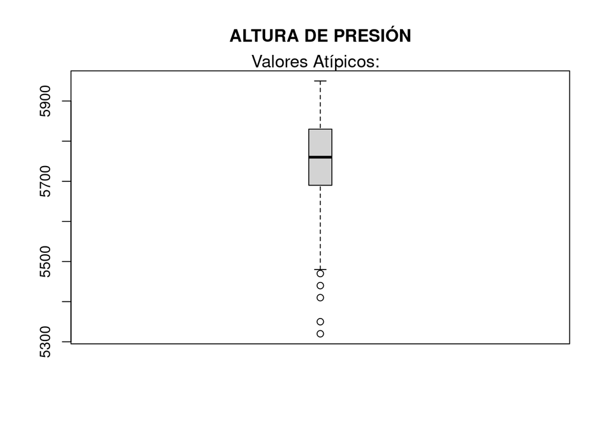

```r
outlier_values = boxplot.stats(ozone$pressure_height)$out
boxplot(ozone$pressure_height, main = "ALTURA DE PRESIÓN", boxwex = 0.1)
mtext(paste("Valores Atípicos:", paste(outlier_values = " ")), cex = 1.2)
```

Las circunferencias con interior de color blanco son los valores atípicos de la variable en cuestión.

#### II.II. Boxplot en Caso Bivariante

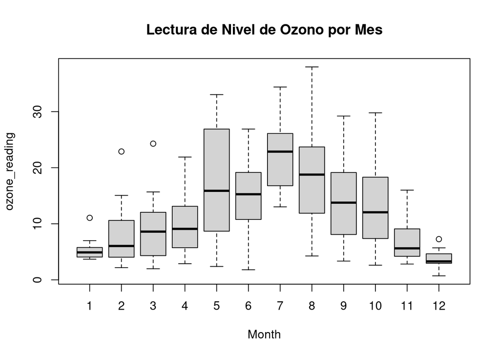

```r
boxplot(ozone_reading ~ Month, data = ozone, main = "Lectura de Nivel de Ozono por Mes")
```

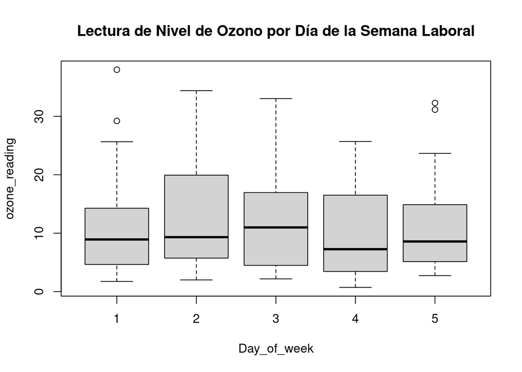

```r
boxplot(ozone_reading ~ Day_of_week, data = ozone, main = "Lectura de Nivel de Ozono por Día de la Semana Laboral")
```

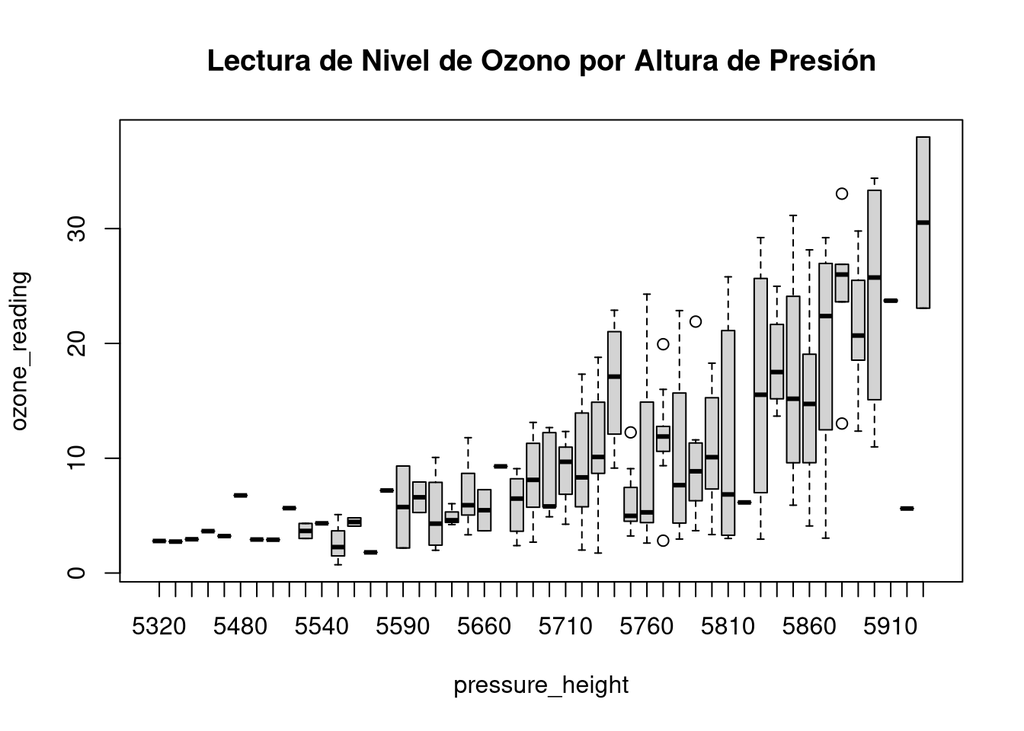

```r
boxplot(ozone_reading ~ pressure_height, data = ozone, main = "Lectura de Nivel de Ozono por Altura de Presión")
```

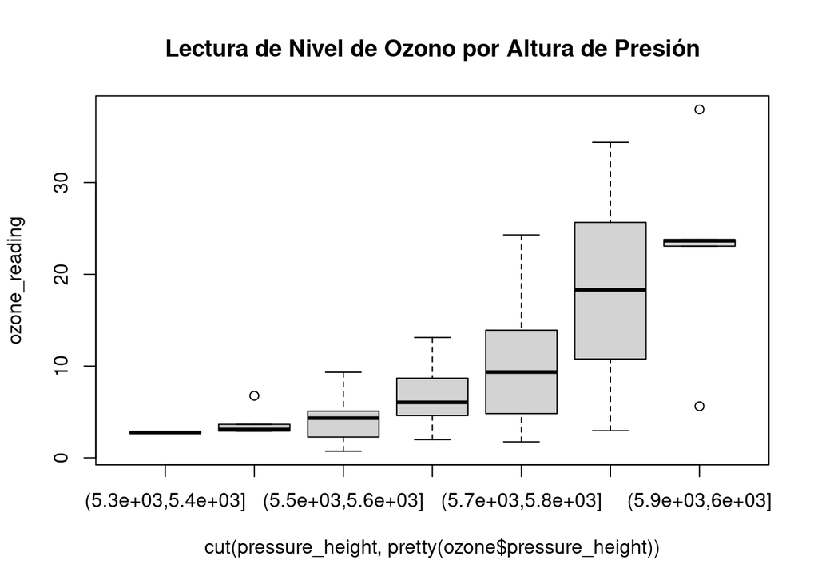

```r
boxplot(ozone_reading ~ cut(pressure_height, pretty(ozone$pressure_height)), data = ozone, main = "Lectura de Nivel de Ozono por Altura de Presión") #Discretizando (convertido en variable categórica)
```

### III. CASO MULTIVARIANTE

#### III.I. Distancia de Cook

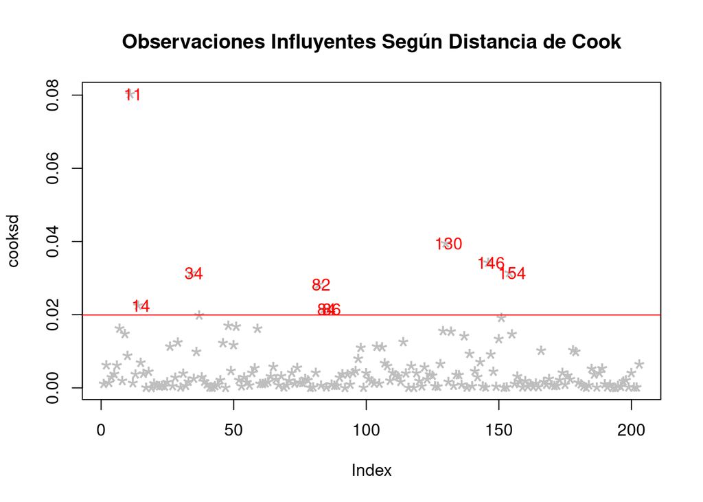

```r
mod = lm(ozone_reading ~ ., data = ozone)

cooksd = cooks.distance(mod)
plot(cooksd, pch = "*", cex = 2, main = "Observaciones Influyentes Según Distancia de Cook", col = "grey")
abline(h = 4*mean(cooksd, na.rm = T), col = "red")
text(x = 1: length(cooksd) + 1, y = cooksd, labels = ifelse(cooksd > 4*mean(cooksd, na.rm = T), names(cooksd), ""), col = "red")
```

```r
influyentes = as.numeric(names(cooksd)[(cooksd > 4*mean(cooksd, na.rm = T))])
head(ozone[influyentes,])
```

```
##    Month Day_of_month Day_of_week ozone_reading pressure_height Wind_speed
## 11     1           19           1          4.07            5680          5
## 14     1           23           5          4.90            5700          5
## 34     2           27           5         22.89            5740          3
## 82     5           12           3         33.04            5880          3
## 84     5           14           5         31.15            5850          4
## 86     5           28           5          4.82            5750          3
##    Humidity Temperature_Sandburg Temperature_ElMonte Inversion_base_height
## 11       73                   52               56.48                   393
## 14       59                   69               51.08                  3044
## 34       47                   53               58.82                   885
## 82       80                   80               73.04                   436
## 84       76                   78               71.24                  1181
## 86       76                   65               51.08                  3644
##    Pressure_gradient Inversion_temperature Visibility
## 11               -68                 69.80         10
## 14                18                 52.88        150
## 34                -4                 67.10         80
## 82                 0                 86.36         40
## 84                50                 79.88         17
## 86                86                 59.36         70
```

#### III.II. Residuales de Bonferroni

**Descripción**

La prueba de valores atípicos de Bonferroni es un método estadístico utilizado para identificar valores atípicos (outliers) en un conjunto de datos. La prueba utiliza los valores p ajustados de Bonferroni para evaluar si cada observación individual se comporta como un valor atípico en términos de su impacto en el cambio medio. Se aplica en el contexto de modelos estadísticos específicos, incluyendo modelos lineales, modelos lineales generalizados y modelos lineales mixtos.

Se utiliza un umbral o límite (“cutoff”) para decidir si considerar una observación como un valor atípico (outlier) basado en los resultados de la prueba de valores atípicos.

El parámetro cutoff representa el nivel de significancia o probabilidad crítica que se utiliza para comparar con los valores p obtenidos de la prueba de valores atípicos. Si el valor p de una observación es menor que el cutoff, se considerará como un valor atípico. Por lo que los resultados de esta prueba sólo arrojará como atípicos aquellos valores cuyo valor p sea inferior al umbral pre-establecido.

**Detalles**

1. Valores p de Bonferroni: La prueba genera valores p ajustados utilizando el método de Bonferroni. La corrección de Bonferroni se utiliza para controlar el error de tipo I cuando se realizan múltiples comparaciones. Cada valor p ajustado refleja la probabilidad de observar un valor tan extremo o más extremo bajo la hipótesis nula de que no hay valores atípicos.
2. Residuos Studentizados: La prueba se basa en residuos studentizados, que son medidas estandarizadas de la diferencia entre los valores observados y los valores predichos en el modelo. Los residuos studentizados son útiles para evaluar la influencia de observaciones individuales en el ajuste del modelo.
3. Modelos compatibles: La prueba es aplicable a diferentes tipos de modelos estadísticos, incluyendo modelos lineales (donde se realizan pruebas t), modelos lineales generalizados (donde se realizan pruebas normales) y modelos lineales mixtos.

**Propósito**

El propósito principal de esta prueba es identificar observaciones que tienen un impacto significativo en el ajuste del modelo y que podrían considerarse como valores atípicos en términos de su influencia en la estimación de los parámetros del modelo y las conclusiones derivadas de él. La corrección de Bonferroni ayuda a controlar el riesgo de hacer conclusiones incorrectas debido a la realización de múltiples pruebas.

En resumen, la prueba de valores atípicos de Bonferroni es una herramienta estadística que proporciona una evaluación ajustada de los valores p para identificar observaciones inusuales en diferentes tipos de modelos estadísticos.

```r
library(car)
outlierTest(mod)
```

```
## No Studentized residuals with Bonferroni p < 0.05
## Largest |rstudent|:
##     rstudent unadjusted p-value Bonferroni p
## 130 3.045756          0.0026525      0.53845
```

El primer número arrojado (130) es el outlier más crítico.

#### III.III. Detección de Outliers por Transformaciones Sobre los Datos y Fijación Apriorística de Umbrales

```r
library(outliers)

set.seed(2000)
y = rnorm(100)

outlier(y) #esta función encuentra el valor con la mayor diferencia entre él y la media de la muestra, lo que puede ser un valor atípico.
```

```
## [1] -2.419771
```

```r
outlier(y, opposite = TRUE) #cuando el argumento "opposite" se establece en TRUE, proporciona el valor opuesto: si el valor más grande tiene la diferencia máxima con la media (que la magnitud de la diferencia entre dos valores -la observación analizada, por un lado, y la media por otro lado- es la mayor posible), proporciona el más pequeño y viceversa. En otras palabras, si "opposite = FALSE" daba el outlier más negativo, "opposite = TRUE" dará el outlier más positivo y viceversa.
```

```
## [1] 2.094378
```

```r
dim(y) = c(20, 5) #convertir en una matriz con 20 filas y 5 columnas, para considerar "y" como un objeto con forma de una base de datos. Así, ya no detectará un sólo valor, sino que detectará cuáles valores son outlier para cada columna.

outlier(y)
```

```
## [1] -1.938438 -1.764390 -1.476490 -2.014643 -2.419771
```

```r
outlier(y, opposite = TRUE)
```

```
## [1] 2.094378 1.164901 1.548503 1.002279 1.867821
```

```r
set.seed(2000)
x = rnorm(100)

scores(x) #por defecto arrojará puntajes z, es decir, estandariza los datos. En estadísticas, las "puntuaciones" generalmente se refieren a valores numéricos calculados para cada observación en un conjunto de datos con el propósito de resumir o describir alguna característica o propiedad de esas observaciones. En este caso, la transformacion que realiza la funcion es la de estandarizar los datos (restarle a cada observacion la media y dividir cada uno de esos resultados entre la desviación estándar)
```

```
##   [1] -0.91393827 -0.38732935  0.91936867  1.81409469  0.94662536 -1.25322571
##   [7] -2.05407794  2.18526913  0.22065437  1.22014846  1.97270889  0.86273438
##  [13]  1.40201930 -0.21867186  0.18664471  1.12171191 -1.24371220  0.18430073
##  [19] -1.24399220 -0.23346114  0.46194951 -1.87111617  0.45357865  0.75504295
##  [25]  0.37668767 -0.07968903 -1.55924468 -1.80419733  0.02599908  1.20819135
##  [31] -1.11735662 -0.62680637 -0.87308617 -1.09005481 -1.06872169 -0.43414448
##  [37]  0.71325366  0.54998402 -0.12198044 -0.44121623 -0.02093412 -1.29512045
##  [43]  0.44945198  0.30911494  1.61143809  0.89229754  0.98545120 -0.57024823
##  [49]  0.63970373  0.57000487  0.80818858 -0.55477530 -1.25463720 -0.98231701
##  [55] -1.56847271  0.93077537  1.03244354  0.30224476 -0.70434303  0.97283066
##  [61]  1.03724011 -0.14591536 -0.30767886  0.14065520 -1.29132211  0.34663125
##  [67]  0.93764425  0.51928945 -2.13418563  0.01206521 -0.12122274 -0.71302745
##  [73] -1.70478407 -0.60675276 -0.55598134  0.69716029 -0.65816648  0.27181682
##  [79]  0.73654124  0.83728078 -0.48546668 -0.44041661 -0.31076372  0.36274506
##  [85]  0.75015493  0.04015862  1.81000463 -0.15560724 -0.59701831  0.83166923
##  [91] -0.14404653  0.94345143  1.94710959 -0.72679359  0.45035305  0.28840727
##  [97]  0.85532770 -2.56006122 -1.28198926 -0.37254813
```

```r
scores(x, type = "z", prob = 0.9) #Si prob es igual a 1, la función devolverá los valores p correspondientes en lugar de las puntuaciones. Cuando se utiliza el parámetro prob con un valor distinto de 1, se está diciendo básicamente: "Quiero saber qué valores de mi conjunto de datos son mayores que cierta probabilidad". Supongamos que prob es 0.9, por ejemplo. Esto significa que se está interesado en saber qué valores están en el 10% superior del conjunto de datos. La función devolverá un vector donde cada posición dirá si el valor en esa posición está en el 10% superior o no. Lo anterior puede servir para, una vez transformados los datos, identificar valores extremos o atípicos en la cola superior del conjunto de datos analizado. Si los elementos del vector resultante son TRUE, significa que esos valores están en la cola superior y superan el umbral de probabilidad que especifico (este umbral es establecido apriorísticamente según el criterio experto del investigador).
```

```
##   [1] FALSE FALSE FALSE  TRUE FALSE FALSE  TRUE  TRUE FALSE FALSE  TRUE FALSE
##  [13]  TRUE FALSE FALSE FALSE FALSE FALSE FALSE FALSE FALSE  TRUE FALSE FALSE
##  [25] FALSE FALSE  TRUE  TRUE FALSE FALSE FALSE FALSE FALSE FALSE FALSE FALSE
##  [37] FALSE FALSE FALSE FALSE FALSE  TRUE FALSE FALSE  TRUE FALSE FALSE FALSE
##  [49] FALSE FALSE FALSE FALSE FALSE FALSE  TRUE FALSE FALSE FALSE FALSE FALSE
##  [61] FALSE FALSE FALSE FALSE  TRUE FALSE FALSE FALSE  TRUE FALSE FALSE FALSE
##  [73]  TRUE FALSE FALSE FALSE FALSE FALSE FALSE FALSE FALSE FALSE FALSE FALSE
##  [85] FALSE FALSE  TRUE FALSE FALSE FALSE FALSE FALSE  TRUE FALSE FALSE FALSE
##  [97] FALSE  TRUE  TRUE FALSE
```

```r
scores(x, type = "chisq") #Estas puntuaciones son los cuadrados de las diferencias entre cada valor y la media, divididos por la varianza.
```

```
##   [1] 0.8352831651 0.1500240244 0.8452387465 3.2909395564 0.8960995696
##   [6] 1.5705746769 4.2192362035 4.7754011558 0.0486883511 1.4887622551
##  [11] 3.8915803720 0.7443106028 1.9656581172 0.0478173835 0.0348362470
##  [16] 1.2582376073 1.5468200392 0.0339667584 1.5475166006 0.0545041043
##  [21] 0.2133973502 3.5010757128 0.2057335955 0.5700898576 0.1418936008
##  [26] 0.0063503417 2.4312439798 3.2551280148 0.0006759519 1.4597263402
##  [31] 1.2484858105 0.3928862299 0.7622794657 1.1882194877 1.1421660539
##  [36] 0.1884814301 0.5087307886 0.3024824254 0.0148792288 0.1946717603
##  [41] 0.0004382374 1.6773369810 0.2020070783 0.0955520472 2.5967327089
##  [46] 0.7961948912 0.9711140771 0.3251830391 0.4092208649 0.3249055468
##  [51] 0.6531687812 0.3077756353 1.5741145100 0.9649466994 2.4601066359
##  [56] 0.8663427839 1.0659396630 0.0913518971 0.4960991030 0.9463994902
##  [61] 1.0758670372 0.0212912912 0.0946662806 0.0197838840 1.6675128008
##  [66] 0.1201532260 0.8791767447 0.2696615284 4.5547483114 0.0001455694
##  [71] 0.0146949534 0.5084081419 2.9062887096 0.3681489133 0.3091152486
##  [76] 0.4860324747 0.4331831140 0.0738843833 0.5424929931 0.7010390991
##  [81] 0.2356778985 0.1939667888 0.0965740895 0.1315839752 0.5627324249
##  [86] 0.0016127145 3.2761167688 0.0242136137 0.3564308616 0.6916737108
##  [91] 0.0207494018 0.8901006066 3.7912357676 0.5282289265 0.2028178689
##  [96] 0.0831787512 0.7315854774 6.5539134492 1.6434964567 0.1387921090
```

```r
scores(x, type = "chisq", prob = 0.9)
```

```
##   [1] FALSE FALSE FALSE  TRUE FALSE FALSE  TRUE  TRUE FALSE FALSE  TRUE FALSE
##  [13] FALSE FALSE FALSE FALSE FALSE FALSE FALSE FALSE FALSE  TRUE FALSE FALSE
##  [25] FALSE FALSE FALSE  TRUE FALSE FALSE FALSE FALSE FALSE FALSE FALSE FALSE
##  [37] FALSE FALSE FALSE FALSE FALSE FALSE FALSE FALSE FALSE FALSE FALSE FALSE
##  [49] FALSE FALSE FALSE FALSE FALSE FALSE FALSE FALSE FALSE FALSE FALSE FALSE
##  [61] FALSE FALSE FALSE FALSE FALSE FALSE FALSE FALSE  TRUE FALSE FALSE FALSE
##  [73]  TRUE FALSE FALSE FALSE FALSE FALSE FALSE FALSE FALSE FALSE FALSE FALSE
##  [85] FALSE FALSE  TRUE FALSE FALSE FALSE FALSE FALSE  TRUE FALSE FALSE FALSE
##  [97] FALSE  TRUE FALSE FALSE
```

```r
scores(x, type = "chisq", prob = 0.95)
```

```
##   [1] FALSE FALSE FALSE FALSE FALSE FALSE  TRUE  TRUE FALSE FALSE  TRUE FALSE
##  [13] FALSE FALSE FALSE FALSE FALSE FALSE FALSE FALSE FALSE FALSE FALSE FALSE
##  [25] FALSE FALSE FALSE FALSE FALSE FALSE FALSE FALSE FALSE FALSE FALSE FALSE
##  [37] FALSE FALSE FALSE FALSE FALSE FALSE FALSE FALSE FALSE FALSE FALSE FALSE
##  [49] FALSE FALSE FALSE FALSE FALSE FALSE FALSE FALSE FALSE FALSE FALSE FALSE
##  [61] FALSE FALSE FALSE FALSE FALSE FALSE FALSE FALSE  TRUE FALSE FALSE FALSE
##  [73] FALSE FALSE FALSE FALSE FALSE FALSE FALSE FALSE FALSE FALSE FALSE FALSE
##  [85] FALSE FALSE FALSE FALSE FALSE FALSE FALSE FALSE FALSE FALSE FALSE FALSE
##  [97] FALSE  TRUE FALSE FALSE
```

```r
scores(x, type = "t") #Estas puntuaciones son transformadas por una fórmula que involucra el tamaño de la muestra y se utilizan en el contexto de la distribución t-Student.
```

```
##   [1] -0.91317117 -0.38566050  0.91864359  1.83567784  0.94612395 -1.25688998
##   [7] -2.08867013  2.22861895  0.21959113  1.22320255  2.00247248  0.86161110
##  [13]  1.40897828 -0.21761722  0.18573235  1.12319274 -1.24719662  0.18339902
##  [19] -1.24748186 -0.23234302  0.46010666 -1.89545967  0.45175168  0.75339225
##  [25]  0.37504925 -0.07928808 -1.57075695 -1.82532126  0.02586752  1.21103522
##  [31] -1.11877588 -0.62487380 -0.87202916 -1.09110310 -1.06949772 -0.43235804
##  [37]  0.71147260  0.54803715 -0.12137194 -0.43941445 -0.02082817 -1.29961946
##  [43]  0.44763318  0.30769832  1.62472845  0.89137115  0.98530600 -0.56829497
##  [49]  0.63778422  0.56805165  0.80676224 -0.55282629 -1.25832846 -0.98214137
##  [55] -1.58028929  0.93014130  1.03279106  0.30085324 -0.70253917  0.97256473
##  [61]  1.03764183 -0.14519215 -0.30626745  0.13995700 -1.29574253  0.34508562
##  [67]  0.93706678  0.51736521 -2.17397810  0.01200413 -0.12061791 -0.71124579
##  [73] -1.72161062 -0.60480616 -0.55403185  0.69533930 -0.65627133  0.27054150
##  [79]  0.73482798  0.83600658 -0.48358456 -0.43861653 -0.30934114  0.36114845
##  [85]  0.74848695  0.03995561  1.83139730 -0.15483829 -0.59506759  0.83036402
##  [91] -0.14333219  0.94292287  1.97544513 -0.72505049  0.44853245  0.28706759
##  [97]  0.85415876 -2.63584048 -1.28621906 -0.37092189
```

```r
scores(x, type = "t", prob = 0.9)
```

```
##   [1] FALSE FALSE FALSE  TRUE FALSE FALSE  TRUE  TRUE FALSE FALSE  TRUE FALSE
##  [13]  TRUE FALSE FALSE FALSE FALSE FALSE FALSE FALSE FALSE  TRUE FALSE FALSE
##  [25] FALSE FALSE  TRUE  TRUE FALSE FALSE FALSE FALSE FALSE FALSE FALSE FALSE
##  [37] FALSE FALSE FALSE FALSE FALSE  TRUE FALSE FALSE  TRUE FALSE FALSE FALSE
##  [49] FALSE FALSE FALSE FALSE FALSE FALSE  TRUE FALSE FALSE FALSE FALSE FALSE
##  [61] FALSE FALSE FALSE FALSE  TRUE FALSE FALSE FALSE  TRUE FALSE FALSE FALSE
##  [73]  TRUE FALSE FALSE FALSE FALSE FALSE FALSE FALSE FALSE FALSE FALSE FALSE
##  [85] FALSE FALSE  TRUE FALSE FALSE FALSE FALSE FALSE  TRUE FALSE FALSE FALSE
##  [97] FALSE  TRUE FALSE FALSE
```

```r
scores(x, type = "iqr", prob = 0.9) #Estas puntuaciones se calculan utilizando el rango intercuartílico, la diferencia entre el tercer y primer cuartil.
```

```
##   [1] -0.19907106  0.00000000  0.10765639  0.74539088  0.12708416 -0.44090520
##   [7] -1.01172920  1.00995314  0.00000000  0.32204341  0.85844643  0.06728913
##  [13]  0.45167562  0.00000000  0.00000000  0.25188072 -0.43412425  0.00000000
##  [19] -0.43432383  0.00000000  0.00000000 -0.88131941  0.00000000  0.00000000
##  [25]  0.00000000  0.00000000 -0.65902656 -0.83362163  0.00000000  0.31352074
##  [31] -0.34406170  0.00000000 -0.16995288 -0.32460177 -0.30939615  0.00000000
##  [37]  0.00000000  0.00000000  0.00000000  0.00000000  0.00000000 -0.47076655
##  [43]  0.00000000  0.00000000  0.60094319  0.08836088  0.15475809  0.00000000
##  [49]  0.00000000  0.00000000  0.02841049  0.00000000 -0.44191127 -0.24780942
##  [55] -0.66560402  0.11578675  0.18825285  0.00000000 -0.04967771  0.14576253
##  [61]  0.19167170  0.00000000  0.00000000  0.00000000 -0.46805920  0.00000000
##  [67]  0.12068269  0.00000000 -1.06882761  0.00000000  0.00000000 -0.05586771
##  [73] -0.76276276  0.00000000  0.00000000  0.00000000 -0.01676442  0.00000000
##  [79]  0.00000000  0.04914655  0.00000000  0.00000000  0.00000000  0.00000000
##  [85]  0.00000000  0.00000000  0.74247560  0.00000000  0.00000000  0.04514681
##  [91]  0.00000000  0.12482188  0.84020000 -0.06567982  0.00000000  0.00000000
##  [97]  0.06200987 -1.37237925 -0.46140702  0.00000000
```

```r
scores(x, type = "mad", prob = 0.9) #Estas puntuaciones son las diferencias entre cada valor y la mediana, divididas por la desviación absoluta de la mediana.
```

```
##   [1] FALSE FALSE FALSE  TRUE FALSE FALSE  TRUE  TRUE FALSE FALSE  TRUE FALSE
##  [13]  TRUE FALSE FALSE FALSE FALSE FALSE FALSE FALSE FALSE  TRUE FALSE FALSE
##  [25] FALSE FALSE  TRUE  TRUE FALSE FALSE FALSE FALSE FALSE FALSE FALSE FALSE
##  [37] FALSE FALSE FALSE FALSE FALSE FALSE FALSE FALSE  TRUE FALSE FALSE FALSE
##  [49] FALSE FALSE FALSE FALSE FALSE FALSE  TRUE FALSE FALSE FALSE FALSE FALSE
##  [61] FALSE FALSE FALSE FALSE FALSE FALSE FALSE FALSE  TRUE FALSE FALSE FALSE
##  [73]  TRUE FALSE FALSE FALSE FALSE FALSE FALSE FALSE FALSE FALSE FALSE FALSE
##  [85] FALSE FALSE  TRUE FALSE FALSE FALSE FALSE FALSE  TRUE FALSE FALSE FALSE
##  [97] FALSE  TRUE FALSE FALSE
```

## B. MANEJO DE OUTLIERS

Acá se hará énfasis en procedimientos en R para el tratamiento de “outliers” fuera de los métodos convencionales y básicos. Primero, se presentará una idea de lo que es el contexto de posibilidades de aplicación en el caso del tratamiento de los “outliers”:

1. **Eliminación**: La gran mayoría de autores, lo que recomiendan ante la evidencia de la presencia tras la detección de valores extremos, es tomar una decisión. Algunos son directamente enfáticos en recomendar la eliminación, que es un camino posible, dado que encontramos una explicación racional para los valores del “outlier”, y otros procedimientos involucran, no necesariamente suprimirlo porque eso puede generar un dato faltante adicional en los registros, que debería ser normalmente reemplazado por otro para no perder información.
2. **Eliminación e Imputación** : Algunos lo que sugieren es trabajar con técnicas correspondientes a la imputación de datos, es decir, tras la eliminación tratarlo como un “missing”.
3. **Capping**: Otra opción propusta es acotarlos, es decir, cambiar el valor extremo por un valor que sea un valor límite umbral permitido, de tal manera que el efecto del extremo que está fuera de la zona de la regularidad es cambiado por el máximo valor regular posible, a eso se le llama el “capping”.
4. **Eliminación y Estimación**: Finalmente, lo último es bastante parecido en lo que se siguen la imputación con métodos complejos, eliminar el valor pero cambiarlo por algún valor estimado por algún tipo de modelo, donde esta parte del modelo estaría vinculada con la etapa relativa a la capacidad de estimación.

Como resultado que el método 1 no necesita explicación, el método 2 ya se abordó (en el documento relativo al manejo de valores faltantes) y el método 4 está vinculado a la estimación del modelo, en esta sección se especificará únicamente el método de capping.

**Preparación de datos** Se trabajará con la base de datos de ozono, centrándonos en la variable “pressure height”.

**Cálculo de Cuantiles** Se calcularán los cuantiles, en particular los del 25% y 75%, para establecer el rango intercuartílico.

**Definición de Límites y Rango Intercuartílico (IQR)** Se establecerá un objeto llamado “H”, que representa 1.5 veces el rango intercuartílico (IQR).

**Considerar Flexibilidad del Procedimiento** Se señalará que los percentiles 5 y 95 son los recomendados, pero esto se puede ajustar según necesidades, por ejemplo, utilizando percentiles 10 y 90.

**Conclusión** Este procedimiento de “capping” es una estrategia recomendada para manejar outliers, preservando la información y adaptándose a distintos escenarios. Su implementación en R que ofrece flexibilidad para ajustar los percentiles según los requisitos específicos del análisis.

```r
x = ozone$pressure_height

qnt = quantile(x, probs = c(0.25, 0.75), na.rm = T) #Esta función calcula los percentiles de la variable x. probs = c(0.25, 0.75) indica que se deben calcular los percentiles 25 y 75. "na.rm = T" se utiliza para manejar valores faltantes.
caps = quantile(x, probs = c(0.05, 0.95), na.rm = T) #Esta función de R, quantile, calcula los percentiles de la variable x. Específicamente, probs = c(0.05, 0.95) le indica que calcule los percentiles 5 y 95. El parámetro na.rm = T se utiliza para omitir los valores faltantes al calcular los percentiles.

H = 1.5*IQR(x, na.rm = T) #H representa 1.5 veces el rango intercuartílico (IQR), que se utiliza como criterio para identificar valores extremos.

x[x<(qnt[1]-H)] = caps[1] # Los valores en x que son menores que qnt[1] - H se reemplazan por caps[1] (percentil 5).
x[x<(qnt[2]-H)] = caps[2] # Los valores que son menores que qnt[2] - H se reemplazan por caps[2] (percentil 95)
```

En resumen:

Este enfoque de “capping” es una estrategia para controlar valores extremos, limitando su impacto en el análisis de datos y manteniendo la consistencia con los percentiles específicos definidos como límites.

# CASO 2: ANÁLISIS DEL ALQUILER DE VIVIENDAS

## I. ANÁLISIS DE OUTLIERS UNIVARIANTES PARA VARIABLS INDIVIDUALMENTE CONSIDERADAS CON SUS RESPECTIVOS BOXPLOTS

```r
#Cargar datos
Houses_to_rent = read.csv("houses_to_rent_v2.csv", header=TRUE, stringsAsFactors=FALSE)

#Outliers area
outlier_area<- boxplot.stats(Houses_to_rent$Area)$out
outlier_area
```

[output not shown]

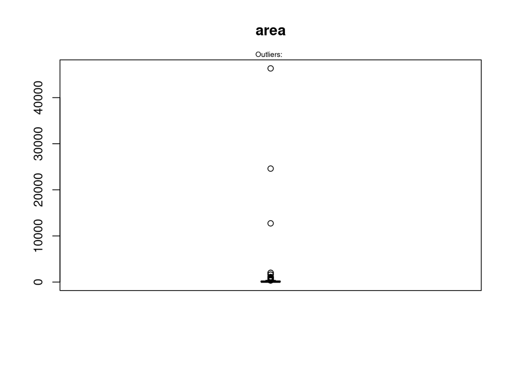

```r
boxplot(Houses_to_rent$area, main="area",boxwex=0.1)
mtext(paste("Outliers: ", paste(outlier_area, collapse=", ")), cex=0.6)
```

```r
#Outliers rooms
outlier_rooms<- boxplot.stats(Houses_to_rent$rooms)$out
outlier_rooms
```

```
##   [1]  7  5  5  8  5  5  5  7  6  6  5  5  5  6  6  6  5  8  5  5  7  5  7  5  5
##  [26]  5  5  7  5  5  6  5  5  5 10  5  5  6  5  5  5  5  5  5  5  5  6  5  6  5
##  [51]  5  5  7  5  5  5  5  5  5  6  5  5  5  5  5  5  6  5  5  5  5  7  6  6  5
##  [76]  7  5  5 10  5  5  6  5  6  5  5  7  7  5  5  5  5  5  5  7  6  5  5  5  5
## [101]  5  6  6  5  5  7  5  5  5  5  6  5  5  5  5  5  5  5  5  5  5  5  6  7  5
## [126]  5  5  5  6  6  7  5  6  5  5  7  5  6  5  5  5  5  5  5  5  5  7  6  6  5
## [151]  5  7  5  5  5  6  5  5  5  6  8  5  5  5  5  5  5  5  5  6  5  5  5  5  5
## [176]  5  5  6  6  5  5  7  5  5  5  5  6  5  5  5  6  6  5  5  5  5  5  7  7  5
## [201]  6  5  5  5  6  5  7  5  5  5  5  6  5  5  5  5 10  5  5  5  5  5  5  7  6
## [226]  5  6  8  5  5  5  5  5  7  5  5  5  5  6  5  6  7  5  5  5  8  7  6  5  5
## [251]  5  5  5  5  5  5  7  5  6  5  5  5  5  5  5  5  5  5  7  5  5  5  5  5  5
## [276]  5  5  8  5  5  5  6  5  5  6  6  5  5  5  5  5  6  6  5  5  6  6  5  7  5
## [301]  5  5  6  5  5  5  5  5  5  5  5  6  5  5  5 13  5  6  7  5  5  5  5  5  5
## [326]  5  7  5  5  5  7  5  5  8  7  5  5  5  7  5  5  5  5  5  5  5  6  6  5  5
## [351]  6  5  5  5  5  5  5  5  5  7  6  5  8  5  8  6  6  5  5  5  5  5  6  6  5
## [376]  9  7  5  5  5  6  5  5  8  5  7  5  5  6  5  5  6  5  5  5  6  5  5  5  5
## [401]  5  5  6  8  5  5  6  6
```

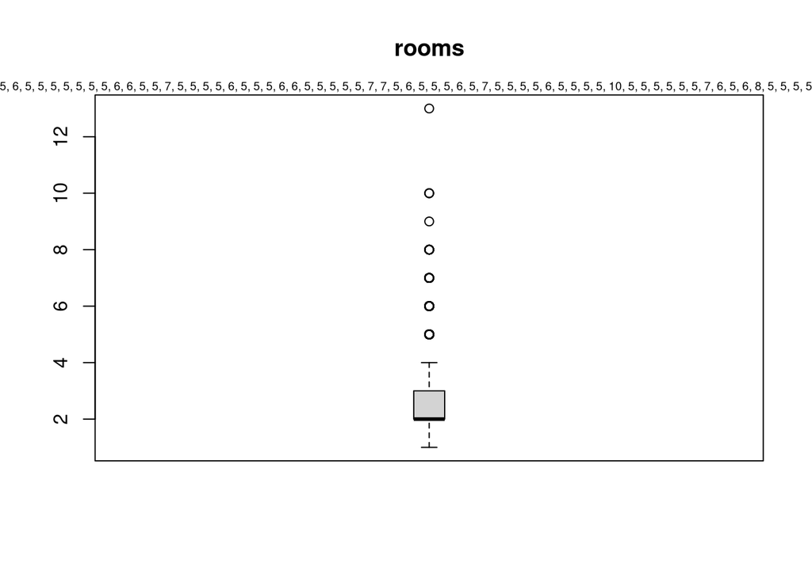

```r
boxplot(Houses_to_rent$rooms, main="rooms",boxwex=0.1)
mtext(paste("Outliers: ", paste(outlier_rooms, collapse=", ")), cex=0.6)
```

```r
#Outliers bathroom
outlier_bathroom <- boxplot.stats(Houses_to_rent$bathroom)$out
outlier_bathroom
```

```
##   [1]  7  9  7  7  7  7  7  7  7  7  9  7  9  7  7  7  7  7  7  7  7  7  7  7  8
##  [26]  7  7 10  7  7  7  7  7  8  7  8  7  7  7  7  7  7  7  7  7  8  7  7  7  7
##  [51]  7  7  7  7  8  7  7  9  8  7  7  7  7  7  7  7  7  7  7  8  7  7  7  7  7
##  [76]  7  7  7  7  7  7  7 10  7  7  7  8  7  7  7 10  7  8  7  7  7  8  7  8  7
## [101]  7  7  7
```

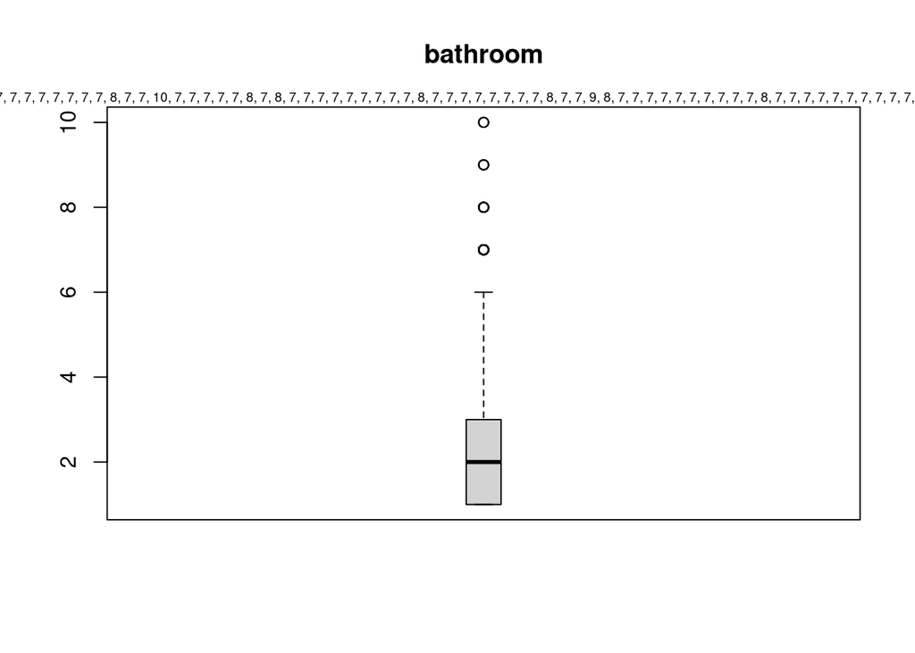

```r
boxplot(Houses_to_rent$ bathroom, main=" bathroom ",boxwex=0.1)
mtext(paste("Outliers: ", paste(outlier_bathroom, collapse=", ")), cex=0.6)
```

```r
#Outliers parkingspaces
outlier_parkingspaces <- boxplot.stats(Houses_to_rent$parking.spaces)$out
outlier_parkingspaces
```

```
##   [1]  7  6  6  8  8  6  8  6  6  7  6  6  8  6  8  6  8  6  6  8  8  8  8  6  6
##  [26]  8  6  8  7  7  8  6  8  8  8  6  6  8  8  8  7  6  7  7  7  6  8  8  6  6
##  [51]  8  6  8  6  8  8  8  8  8  6  8  6  8  6  8  6  8  8  8  8  8  6  8  7  6
##  [76]  6  6  8  6  6  6  8  6  6  6  8  8  6  8  6  6  8  8  6  6  6  8  6  8  6
## [101]  6  7  7  8  6  6  6  8  6  6  8  6  8  6  6  8  6  8  6  8  7  7  8  8  7
## [126]  6 10  6  6  7  6  6  8  6  7  7  6  8  8  6  6  8  6  6  6  6  6  6  6  8
## [151]  8  8  8  6  8  6  6  6  6  7 12  8  6  8  7  8  6  7  6  6  6  8  6  7  6
## [176]  8  7  6 10  6  8  6  6  6  8  8  6  6  8  8  6  8  7  8  6  6  6  8  8  6
## [201]  6  8  6  6  8  6  6  8  6  8  6  8  6  6  8  6  6  6  6  6  8  6  7  6  8
## [226]  6  6  6  8  6  7  8  7  8  6  8  7  8  7  8  8  6  6  6  6  6  6  8  8  6
## [251]  6  8  8  6  6  6  6  6  6  6  6  6  7  6  8  6  6  6  8  8  6  6  8  7  8
## [276]  6  8  6  6  8  6  8  8  8  6  6  8  6  6  8  8  8  8  8  6  8  6  6  8  6
## [301]  8  8  6  6  6  7  6  6  6  6  8  7  8  6  8  6  6  8  8  7  6  8
```

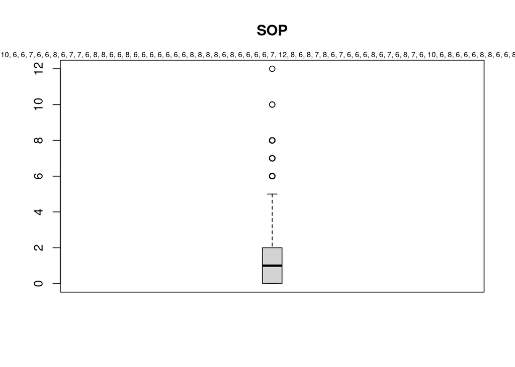

```r
boxplot(Houses_to_rent$parking.spaces, main="SOP",boxwex=0.1)
mtext(paste("Outliers:", paste(outlier_parkingspaces, collapse=", ")), cex=0.6)
```

```r
#Outliers floor
outlier_floor <- boxplot.stats(as.numeric(Houses_to_rent$floor))$out
outlier_floor
```

```
##   [1]  20  24  20  20  26  24  21  22  21  27  22  23  22  26  24  20  35  26
##  [19]  23  20  21  26  23  20  21  20  25  20  26  21  23  25  23  23  24  26
##  [37]  20  46  22  26  20  21  23  25  20  25  21  22  27  26  22  25  25  20
##  [55]  21  28  20  29 301  20  26  27  29  23  25  22  20  20  21  20  23  23
##  [73]  20  23  22  22  26  28  24  25  23  26  24  23  21  24  25  21  22  29
##  [91]  21  23  23  26  21  26  23  21  21  22  24  21  25  21  24  21  21  21
## [109]  20  26  20  25  21  20  27  21  29  25  25  51  22  20  21  24  20  21
## [127]  20  26  29  23  27  32  21  23  24  25  24  22  20  20  26  20  20  25
## [145]  21  22  21  20  21  24  24  25  25  28  26  25  22  24  23  20  23  23
## [163]  27  25  23  25  25  20  20  28  23  28  24  22  26  20  21  25  20  21
## [181]  20  21  20  24  21  20  22  20  20  22  21  20  20  25  24  21  22  21
## [199]  21  21  25  23  25  26  21  23  22  26  22  20  27  20  21  22  24  28
## [217]  20  32  21  22  21  22  27  21
```

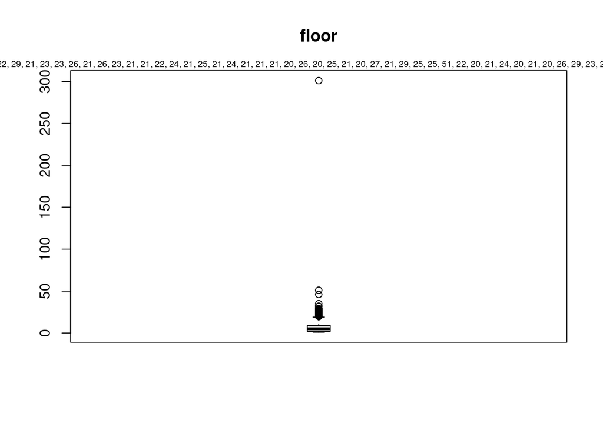

```r
boxplot(as.numeric(Houses_to_rent$floor), main=" floor ",boxwex=0.1)
mtext(paste("Outliers: ", paste(outlier_floor, collapse=", ")), cex=0.6)
```

```r
#Outliers hoa
outlier_hoa <- boxplot.stats(Houses_to_rent$hoa)$out
outlier_hoa
```

```
##   [1]    3700    4000    4052    7400    3366    2884    4800    3000    3500
##  [10]    3500    3000    6660    3000    8300 1117000    3850    6466    3600
##  [19]    4500    3600    3800    3580    3000    6200    2870    3150    4000
##  [28]    4000    4138   14130    4700    2849    4000    3300    5905    2980
##  [37]    9900    3672    3500    3000    4200    3075    4767    2900    3140
##  [46]    3500    4475    3722    3500    3575    3000    8133    3000    3220
##  [55]    4200    7000    3200    3120    2850    4210    3300    4000   10000
##  [64]    3300    3260    4922    3500    3000    3240    8500    2850    5096
##  [73]    5000    5083    4000    3300    3800    3442   15000    3300    6000
##  [82]    3338    4300    3440    3150    3890    7000    3400    2900    3900
##  [91]    8000    3678    5600   32000    4000    4000    3000    3884    3500
## [100]    3200    4360    4200    6000    3800    3150    3000    3168    4400
## [109]    5274    2890    3000    2965    5500    4000    3000    6000    4000
## [118]    4800    3398    3100    3200    3500    3700    5400    3857    4265
## [127]    3450    3340    3270    4208    3800    8600    3000    3450    4100
```

[output cut: 65 more lines]

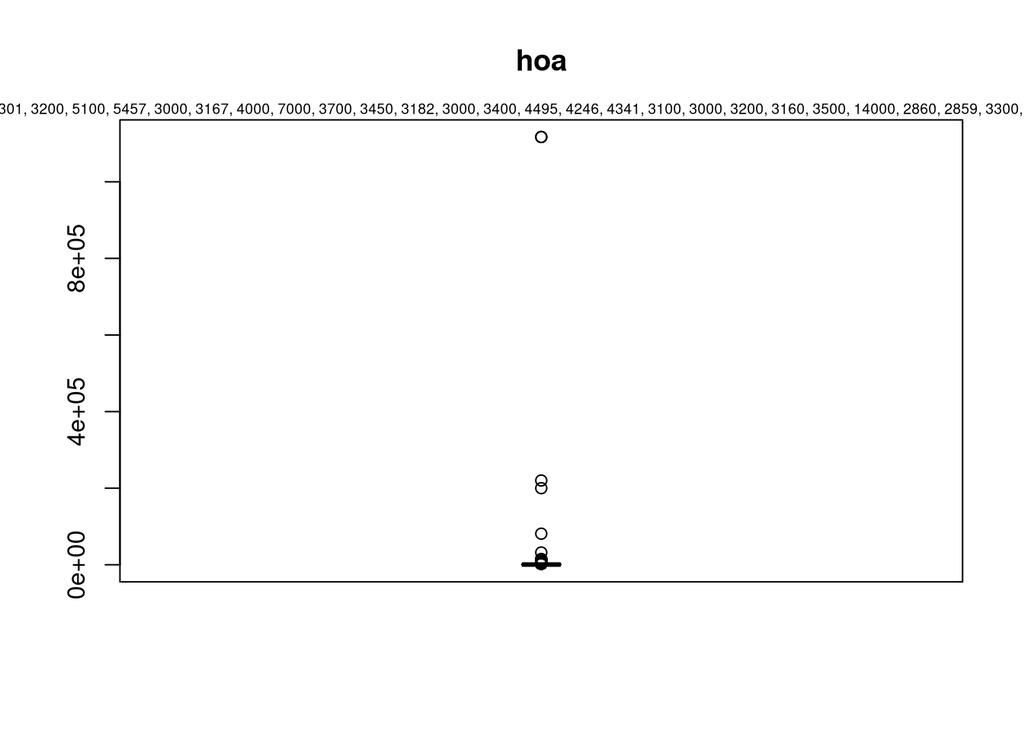

```r
boxplot(Houses_to_rent$hoa, main=" hoa ",boxwex=0.1)
mtext(paste("Outliers:", paste(outlier_hoa, collapse=", ")), cex=0.6)
```

## II. ANÁLISIS DE OUTLIERS MULTIVARIANTES POR DISTANCE DE COOK

```r
(mod <- lm(hoa..R.. ~ ., data=Houses_to_rent))
```

```
##
## Call:
## lm(formula = hoa..R.. ~ ., data = Houses_to_rent)
##
## Coefficients:
##            (Intercept)            cityCampinas        cityPorto Alegre
##             -0.0368611               0.2390581               0.3267276
##     cityRio de Janeiro           citySão Paulo                    area
##              0.2842177              -0.0333040              -0.0000278
##                  rooms                bathroom          parking.spaces
##              0.0777520              -0.0457516               0.0125340
##                 floor1                 floor10                 floor11
##             -0.4860372               0.0062573               0.0569288
##                floor12                 floor13                 floor14
##             -0.0729931               0.1622968              -0.0133796
##                floor15                 floor16                 floor17
##             -0.0921198               0.0501059               0.2183564
##                floor18                 floor19                  floor2
##             -0.0071920               0.1655854              -0.3937084
##                floor20                 floor21                 floor22
##             -0.3429177               0.0031773              -0.6359093
##                floor23                 floor24                 floor25
##              0.1266257              -0.3166030              -1.0165565
##                floor26                 floor27                 floor28
##             -0.0754520               0.2989966               0.7067361
##                floor29                  floor3                floor301
##             -0.1319988              -0.1417527               0.1052646
##                floor32                 floor35                  floor4
##              0.0140000              -4.8185083              -0.5432203
##                floor46                  floor5                 floor51
##             -2.5730746              -0.0304666              -0.0684721
##                 floor6                  floor7                  floor8
##              0.0159227              -0.0092118              -0.0008136
##                 floor9         animalnot acept  furniturenot furnished
##             -0.0290996               0.1770520              -0.1273507
##       rent.amount..R..       property.tax..R..     fire.insurance..R..
##             -0.9997482              -0.9998334              -1.0126604
##             total..R..
##              0.9999029
```

```r
#Crear un modelo de regresión lineal de la variable dependiente hoa versus todas las variables de la base de datos

(cooksd <- cooks.distance(mod))
```

[output not shown]

[output cut: 3509 more lines]

[output not shown]

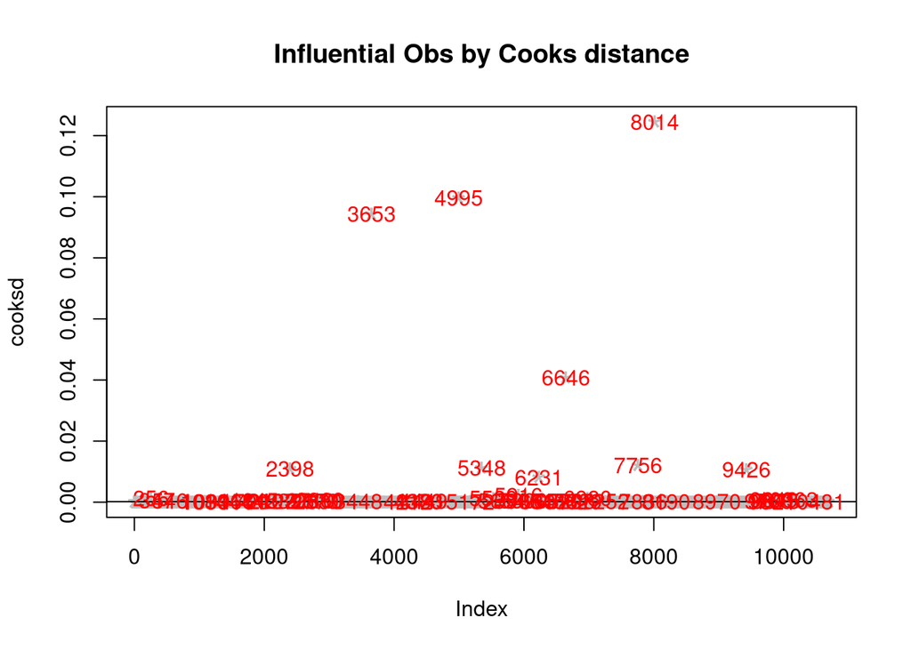

```r
#Se calcula la distancia cook de todos los datos con respecto al modelo lineal

plot(cooksd, pch="*", cex=2, main= "Influential Obs by Cooks distance", col = "grey") #gráfica de las observaciones influenciadas por outliers
abline(h = 4*mean(cooksd, na.rm=T), col="black") #Se añade la linea que diferencia los valores normales de los Outliers
text(x=1:length(cooksd)+1, y=cooksd, labels=ifelse(cooksd>4*mean(cooksd, na.rm=T),names(cooksd),""), col="red")
```

```r
#Se agrega el número de registro de los outliers encontrados en color rojo
influential <- as.numeric(names(cooksd)[(cooksd > 4*mean(cooksd, na.rm=T))])
influential <- influential[!is.na(influential)]
influential
```

```
##  [1]   256   347   546  1080  1099  1444  1661  1700  1845  2107  2123  2396
## [13]  2398  2710  2779  2830  2860  3448  3653  4212  4370  4383  4449  4995
## [25]  5172  5348  5529  5664  5905  5916  5990  6231  6301  6456  6520  6646
## [37]  6728  6829  6980  7252  7756  7836  8014  8190  8970  9426  9768  9821
## [49]  9849  9875 10063 10481
```

```r
(Houses_to_rent[influential, ])
```

```
##                 city  area rooms bathroom parking.spaces floor    animal
## 256   Belo Horizonte   155     1        4              0     4 not acept
## 347   Belo Horizonte   204     4        4              4    22 not acept
## 546        São Paulo   238     4        3              4    24     acept
## 1080       São Paulo   120     2        3              2    19     acept
## 1099       São Paulo   227     3        4              4    18 not acept
## 1444  Rio de Janeiro   190     4        3              2    17     acept
## 1661       São Paulo   500     5        7              5    22     acept
## 1700       São Paulo   700     4        4              4     -     acept
## 1845       São Paulo   172     2        4              3    23     acept
## 2107       São Paulo    98     1        2              0    27     acept
## 2123       São Paulo   240     4        4              4    26     acept
## 2396       São Paulo   270     3        2              4    21     acept
## 2398  Belo Horizonte 46335     4        8              5    11     acept
## 2710       São Paulo   105     1        1              2    29 not acept
```

[output cut: 144 more lines]

```r
#Creamos la variable influential con los registros encontrados fuera del límite establecido
Houses_to_rentvf <- Houses_to_rent[-influential, ] #Obtenemos una nueva base de datos excluyendo a los valores influyentes
Houses_to_rentvf
```

[output not shown]

[output cut: 23065 more lines]

## III. ANÁLISIS DE OUTLIERS MULTIVARIANTES POR BONFERRONI

```r
car::outlierTest(mod)
```

```
##       rstudent unadjusted p-value Bonferroni p
## 3653 -55.64174         0.0000e+00   0.0000e+00
## 4995 -77.26266         0.0000e+00   0.0000e+00
## 8014 -69.71194         0.0000e+00   0.0000e+00
## 7756 -19.26345         2.6148e-81   2.7947e-77
## 5348 -19.18772         1.0719e-80   1.1456e-76
```